# ippolito_week4_park2

### DATA620 - Week4 Part2

#### Michael Ippolito

6/25/2022

Please answer the following questions in an IPython Notebook, posted to GitHub.

1. Choose a corpus of interest.
2. How many total unique words are in the corpus? (Please feel free to define unique words in any interesting, defensible way).
3. Taking the most common words, how many unique words represent half of the total words in the corpus?
4. Identify the 200 highest frequency words in this corpus.
5. Create a graph that shows the relative frequency of these 200 words.
6. Does the observed relative frequency of these words follow Zipf’s law? Explain.
7. In what ways do you think the frequency of the words in this corpus differ from “all words in all corpora.”

[Link to video](https://github.com/mmippolito/cuny_data620_week4_park2/blob/main/ippolito_video.mp4?raw=true)

```python
# Load libraries
from nltk.tokenize import word_tokenize
from nltk.tokenize import RegexpTokenizer
from nltk import FreqDist
import matplotlib.pyplot as plt
import requests
import numpy as np
import pandas as pd
import os
import re
import plotly.express as px
import plotly.io as pio
pio.renderers.default = 'jupyterlab'    # set ploty renderer so graphs show up in HTML output
```

#### 1. Choose a corpus of interest.

```python
# Acquire corpus

# See if we've already downloaded it to disk
fn = 'hemingway.txt'
if not os.path.exists(fn):
    # Download Hemingway's stories
    src = 'https://raw.githubusercontent.com/swglad/hemingway/master/data/corpus/hemingway.txt'
    print("Downloading from " + src)
    print()
    r = requests.get(src)
    fh = open('hemingway.txt', 'w')
    fh.write(r.text)
    fh.close()

# Open local file
print("Opening local file " + fn)
print()
fh = open(fn, 'r')
rawtxt = fh.read()
fh.close()

# Print first 500 characters
print(rawtxt[:500])
```

```
Opening local file hemingway.txt


THE FIRST FORTY - NINE STORIES

by
ERNEST HEMINGWAY


PREFACE

THERE is not much to say about these stories .  The first four
are the last ones I have written .  The others follow in the
order in which they were originally published .

The first one I wrote was Up in Michigan ,  written in
Paris in 1921 .  The last was Old Man at the Bridge ,  cabled
from Barcelona in April of 1938 .

I wrote The Killers ,  To - day Is Friday ,  Ten Indians "  ,
part of Fiesta ,  and the first thi
```

#### 2. How many total unique words are in the corpus? (Please feel free to define unique words in any interesting, defensible way).

```python
# Tokenize raw text and print first few words
#t = word_tokenize(rawtxt)    # use RegexpTokenizer instead to exclude punctution
tokenizer = RegexpTokenizer(r"[A-Za-z_\-']+")    # only use alphabetical characters, underscores, hyphens, and apostrophes
t = tokenizer.tokenize(rawtxt)
print("After tokenizing:")
print(t[:100])
print()

# Remove words that don't have any alphabetical characters
[t.remove(w) for w in t if not re.search(r'[A-Za-z]', w)]

# Get unique set of vocab and convert to lowercase
vocab = sorted(set(t))
vocab = [word.lower() for word in t]
print("Unique vocab:")
print(vocab[:100])
print()
vocab_len = len(vocab)
print("There are " + '{:,}'.format(vocab_len) + " unique words in the corpus.")
```

[output not shown]

#### 3. Taking the most common words, how many unique words represent half of the total words in the corpus?

```python
# Frequency distribution
fdist = FreqDist(vocab)
word_ct = 0
total_ct = 0
for w in fdist.most_common():
    word_ct += 1
    total_ct += w[1]
    if (total_ct / vocab_len) > 0.5:
        break
print(str(word_ct) + " unique words (out of " + '{:,}'.format(vocab_len) + ") account for " + '{:.1f}'.format(100 * total_ct / vocab_len) + "% of words.")
```

```
64 unique words (out of 205,368) account for 50.2% of words.
```

#### 4. Identify the 200 highest frequency words in this corpus.

```python
# Most common 200 highest frequency words
print("The 200 highest frequency words:")
print(fdist.most_common(200))
print()
```

```
The 200 highest frequency words:
[('the', 14406), ('and', 6849), ('i', 4917), ('to', 4774), ('a', 4474), ('he', 3626), ('you', 3421), ('it', 3194), ('of', 3171), ('in', 3169), ('was', 3166), ('said', 2860), ('that', 1733), ('on', 1693), ('his', 1662), ('had', 1457), ('they', 1439), ('with', 1431), ('we', 1302), ('not', 1295), ('wer…
```

#### 5. Create a graph that shows the relative frequency of these 200 words.

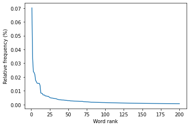

```python
# Generate x and y, where x is the rank, y is the relative frequency of the word
x = list(range(1, 201))
y = [word[1]/vocab_len for word in fdist.most_common(200)]

# Plot
plt.plot(x, y)
plt.xlabel('Word rank')
plt.ylabel('Relative frequency (%)')
plt.show()
```

#### 6. Does the observed relative frequency of these words follow Zipf’s law? Explain.

Zipf's Law: \ Let f(w) be the frequency of a word w in free text. Suppose that all the words of a text are ranked according to their frequency, with the most frequent word first. Zipf's law states that the frequency of a word type is inversely proportional to its rank (i.e. f × r = k, for some constant k). For example, the 50th most common word type should occur three times as frequentlyas the 150th most common word type.

```
Mean: 0.14078186475010712
Median: 0.14231282380896731
Min: 0.06669977795956526
Max: 0.16957851271863192
Std dev: 0.012999458316692969
```

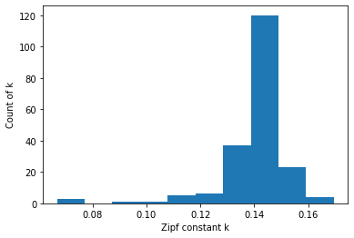

```python
# Generate an array of k values based on frequency * rank arrays generated above
k = np.array(x) * np.array(y)
print('Mean:', k.mean())
print('Median:', np.median(k))
print('Min:', k.min())
print('Max:', k.max())
print('Std dev:', k.std())
print()
plt.hist(k)
plt.xlabel('Zipf constant k')
plt.ylabel('Count of k')
plt.show()
```

#### 7. In what ways do you think the frequency of the words in this corpus differ from “all words in all corpora.”

I think the frequency of words in this corpus is probably very similar to the frequency of all words in all corpora, if we're considering only American English corpora. Hemingway tended to use short words and sentences, so it might be different if we were comparing him to other literary works. But in general I think it would be very similar, even though he wrote a hundred years ago.